# Practicle Machine Learning Project

Mwenge Mulenga

10/28/2020

Task description

Using devices such as Jawbone Up, Nike FuelBand, and Fitbit it is now possible to collect a large amount of data about personal activity relatively inexpensively. These type of devices are part of the quantified self movement – a group of enthusiasts who take measurements about themselves regularly to improve their health, to find patterns in their behavior, or because they are tech geeks. One thing that people regularly do is quantify how much of a particular activity they do, but they rarely quantify how well they do it. In this project, your goal will be to use data from accelerometers on the belt, forearm, arm, and dumbell of 6 participants. They were asked to perform barbell lifts correctly and incorrectly in 5 different ways.

Preloading packages

Downloading and loading the data

```r
train_url <- "http://d396qusza40orc.cloudfront.net/predmachlearn/pml-training.csv"
test_url <- "http://d396qusza40orc.cloudfront.net/predmachlearn/pml-testing.csv"
orig_training <- read.csv(url(train_url),sep = ",", na.strings = c("", "NA"))
orig_testing <- read.csv(url(test_url),sep = ",", na.strings = c("", "NA"))
```

Testing the files for my start point.

```r
dim(orig_training)
```

```
## [1] 19622   160
```

```r
dim(orig_testing)
```

```
## [1]  20 160
```

Analysis of variables that have too many NA values

```r
training.nonNAs <- orig_training[ , colSums(is.na(orig_training)) == 0]
dim(training.nonNAs)
```

```
## [1] 19622    60
```

Cleaning the data

```r
clean_training<-training.nonNAs[,-c(1:8)]
dim(clean_training)
```

```
## [1] 19622    52
```

```r
clean_testing<-orig_testing[,names(clean_training[,-52])]
dim(clean_testing)
```

```
## [1] 20 51
```

Splitting the data into a 75% training set and a 25% test set.

```r
inTrain<-createDataPartition(y=clean_training$classe, p=0.75,list=F)
training<-clean_training[inTrain,]
test<-clean_training[-inTrain,]
dim(training)
```

```
## [1] 14718    52
```

```r
Modfit1<-trainControl(method="cv", number=5, allowParallel=T, verbose=T)
rf_fit<-train(classe~.,data=training, method="rf", trControl=Modfit1, verbose=F)
pred.rf<-predict(rf_fit, newdata=test)
confusionMatrix(pred.rf, test$classe)
```

```
## Confusion Matrix and Statistics
##
##           Reference
## Prediction    A    B    C    D    E
##          A 1392    5    0    0    0
##          B    0  939    5    0    0
##          C    2    5  847    5    1
##          D    0    0    3  799    1
##          E    1    0    0    0  899
##
## Overall Statistics
##
##                Accuracy : 0.9943
##                  95% CI : (0.9918, 0.9962)
##     No Information Rate : 0.2845
##     P-Value [Acc > NIR] : < 2.2e-16
##
##                   Kappa : 0.9928
##
##  Mcnemar's Test P-Value : NA
##
## Statistics by Class:
##
##                      Class: A Class: B Class: C Class: D Class: E
## Sensitivity            0.9978   0.9895   0.9906   0.9938   0.9978
## Specificity            0.9986   0.9987   0.9968   0.9990   0.9998
## Pos Pred Value         0.9964   0.9947   0.9849   0.9950   0.9989
## Neg Pred Value         0.9991   0.9975   0.9980   0.9988   0.9995
## Prevalence             0.2845   0.1935   0.1743   0.1639   0.1837
## Detection Rate         0.2838   0.1915   0.1727   0.1629   0.1833
## Detection Prevalence   0.2849   0.1925   0.1754   0.1637   0.1835
## Balanced Accuracy      0.9982   0.9941   0.9937   0.9964   0.9988
```

```r
pred.20<-predict(rf_fit, newdata=clean_testing)
pred.20
```

```
##  [1] B A B A A E D B A A B C B A E E A B B B
## Levels: A B C D E
```

Plotting with rpart plot

```r
set.seed(1234)
model_fit2 <- rpart(classe ~ ., data=clean_training, method="class")
print(model_fit2)
```

```
## n= 19622
##
## node), split, n, loss, yval, (yprob)
##       * denotes terminal node
##
##    1) root 19622 14042 A (0.28 0.19 0.17 0.16 0.18)
##      2) pitch_forearm< -33.95 1578    10 A (0.99 0.0063 0 0 0) *
##      3) pitch_forearm>=-33.95 18044 14032 A (0.22 0.21 0.19 0.18 0.2)
##        6) accel_belt_z>=-187.5 17009 13003 A (0.24 0.22 0.2 0.19 0.15)
##         12) magnet_dumbbell_y< 439.5 14253 10328 A (0.28 0.18 0.23 0.19 0.13)
##           24) roll_forearm< 123.5 8980  5460 A (0.39 0.17 0.18 0.16 0.095)
##             48) magnet_dumbbell_z< -27.5 2968  1029 A (0.65 0.21 0.013 0.076 0.05)
##               96) roll_forearm>=-136.5 2478   591 A (0.76 0.17 0.013 0.026 0.028) *
##               97) roll_forearm< -136.5 490   297 B (0.11 0.39 0.01 0.33 0.16) *
##             49) magnet_dumbbell_z>=-27.5 6012  4431 A (0.26 0.16 0.26 0.2 0.12)
##               98) yaw_belt>=168.5 750   114 A (0.85 0.079 0.0013 0.067 0.0053) *
##               99) yaw_belt< 168.5 5262  3714 C (0.18 0.17 0.29 0.22 0.13)
##                198) accel_dumbbell_y>=-40.5 4521  3368 D (0.21 0.19 0.21 0.26 0.14)
##                  396) pitch_belt< -42.85 520   104 B (0.031 0.8 0.11 0.025 0.038) *
##                  397) pitch_belt>=-42.85 4001  2861 D (0.23 0.11 0.22 0.28 0.15)
##                    794) yaw_arm< -110.5 267     4 A (0.99 0.015 0 0 0) *
##                    795) yaw_arm>=-110.5 3734  2594 D (0.18 0.12 0.24 0.31 0.16)
##                     1590) pitch_belt>=-40.45 2581  1893 D (0.25 0.16 0.1 0.27 0.23)
##                       3180) pitch_forearm< 0.425 637   265 A (0.58 0.055 0.017 0 0.34)
##                         6360) accel_forearm_x>=56.5 400    43 A (0.89 0.072 0.012 0 0.022) *
##                         6361) accel_forearm_x< 56.5 237    27 E (0.063 0.025 0.025 0 0.89) *
##                       3181) pitch_forearm>=0.425 1944  1256 D (0.13 0.19 0.13 0.35 0.19) *
##                     1591) pitch_belt< -40.45 1153   526 C (0.023 0.03 0.54 0.39 0.011)
##                       3182) yaw_belt< 163.5 488    46 C (0.047 0.018 0.91 0.002 0.027) *
##                       3183) yaw_belt>=163.5 665   214 D (0.0045 0.039 0.28 0.68 0) *
##                199) accel_dumbbell_y< -40.5 741   143 C (0.0081 0.04 0.81 0.028 0.12) *
##           25) roll_forearm>=123.5 5273  3546 C (0.077 0.18 0.33 0.23 0.19)
##             50) magnet_dumbbell_y< 290.5 3093  1615 C (0.091 0.13 0.48 0.15 0.15)
##              100) magnet_forearm_z< -251 238    49 A (0.79 0.071 0 0.046 0.088) *
##              101) magnet_forearm_z>=-251 2855  1377 C (0.033 0.14 0.52 0.15 0.16)
##                202) pitch_belt>=26.15 189    39 B (0.1 0.79 0.032 0 0.074) *
##                203) pitch_belt< 26.15 2666  1194 C (0.028 0.09 0.55 0.16 0.17) *
##             51) magnet_dumbbell_y>=290.5 2180  1430 D (0.056 0.24 0.11 0.34 0.25)
##              102) accel_forearm_x>=-101.5 1398   923 E (0.051 0.3 0.16 0.15 0.34)
##                204) magnet_arm_y>=188.5 573   267 B (0.014 0.53 0.23 0.1 0.12) *
##                205) magnet_arm_y< 188.5 825   420 E (0.076 0.15 0.11 0.18 0.49) *
##              103) accel_forearm_x< -101.5 782   237 D (0.066 0.12 0.036 0.7 0.077) *
##         13) magnet_dumbbell_y>=439.5 2756  1470 B (0.029 0.47 0.039 0.21 0.26)
##           26) total_accel_dumbbell>=5.5 1948   774 B (0.042 0.6 0.054 0.019 0.28)
##             52) gyros_belt_z>=-0.255 1721   554 B (0.047 0.68 0.062 0.02 0.19) *
##             53) gyros_belt_z< -0.255 227    10 E (0 0.031 0 0.013 0.96) *
##           27) total_accel_dumbbell< 5.5 808   277 D (0 0.14 0.0025 0.66 0.2)
##             54) yaw_belt< 16.475 652   121 D (0 0.17 0.0031 0.81 0.011) *
##             55) yaw_belt>=16.475 156     0 E (0 0 0 0 1) *
##        7) accel_belt_z< -187.5 1035     7 E (0.0058 0.00097 0 0 0.99) *
```

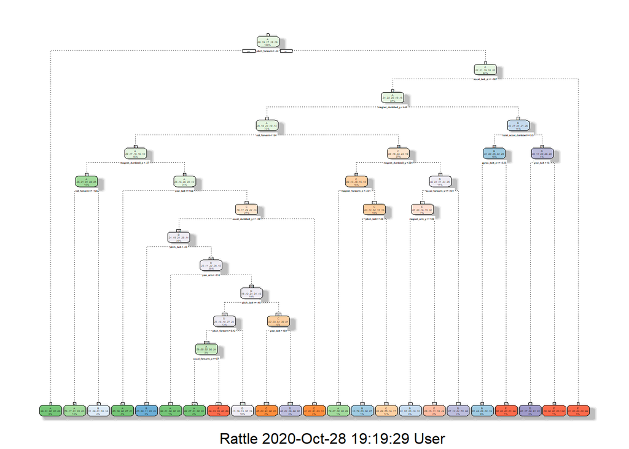

```r
fancyRpartPlot(model_fit2, digits=2)
```

Predicting on the test data

result <-predict(rf_fit,clean_testing[ , -length(names(clean_testing))])